# Calcul des profils de cyclistes et cartographie de leur localisation dans la ville

[Maëlle Lucas](https://perso.univ-rennes2.fr/maelle.lucas) et [Florent Demoraes](https://perso.univ-rennes2.fr/florent.demoraes)

18/11/2022 - Mise à jour 20/10/2023

# 1 Calcul des profils de cyclistes à l’aide d’une AFDM couplée à une CAH

## 1.1 Chargement des packages nécessaires

```r
library(FactoMineR)# Pour executer des analyses factorielles (telle que l'AFDM) et des classifications (type CAH)
library(openxlsx) # Pour importer/exporter depuis/vers Excel
library(sf) # pour manipuler les objets ayant une composante spatiale
library(spatstat) # pour le lissage spatial
library(cartography) # pour la représentation cartographique et l'habillage des cartes
library(terra) # pour le traitement de données matricielles (raster)
library(factoextra) # pour améliorer le rendu des graphiques
```

## 1.2 Importation des données en entrée (fichier Excel)

```r
# import du tableau des individus ayant utilisé la veille de l'enquête, le vélo comme mode principal pour se déplacer dans la ville
Cyclistes <- read.xlsx("Cyclistes.xlsx", sheet = "VariablesCyclistes")
rownames(Cyclistes) <- Cyclistes$id_hog_pers # pour ajouter l'id des personnes comme entête de ligne
Cyclistes$id_hog_pers <- NULL # pour supprimer la colonne
head(Cyclistes)
```

```
##             Edad   Sexo      NivEducCL  LicCondu Ocasional DuracionCL MotivoCL
## P00316-4 Inf. 15  Mujer PrimariaSecund LicCon-No   Ocas-No    Inf. 30  Estudio
## 12861-1    40-64  Mujer  Universitario LicCon-No   Ocas-No    Inf. 30     Otro
## 5636-4   Inf. 15  Mujer PrimariaSecund LicCon-No   Ocas-No    Inf. 30  Estudio
## 10497-3    15-39 Hombre          Media LicCon-No   Ocas-Si      60-89     Otro
## P05845-6   15-39 Hombre          Media LicCon-No   Ocas-No      30-59     Trab
## 6973-1     40-64 Hombre PrimariaSecund LicCon-Si   Ocas-No    Inf. 30     Trab
##          Estrato  LugResid  GranZona DistanciaCL Duracion Distancia PartModInd
## P00316-4   Estr2  MOSQUERA Periferia      2-4 km       16      2480      100.0
## 12861-1    Estr2  MOSQUERA Periferia    Inf 2 km       10       742      100.0
## 5636-4     Estr0    SOACHA       Sur      2-4 km       15      2056      100.0
## 10497-3    Estr5  FONTIBON     Oeste    Inf 2 km       60       819      100.0
## P05845-6   Estr0 TOCANCIPA Periferia 15 km y más       30     27647      100.0
## 6973-1     Estr2    MADRID Periferia     6-10 km       15      8532       66.6
##          Experi NumViajDia FrecSemana FrecFinSem NumAuto NumMoto NumPersHog
## P00316-4    5.0          2        5.0          0       0       2          5
## 12861-1     5.0          4        5.0          0       0       0          2
## 5636-4      1.5          2        4.5          0       0       0          4
## 10497-3     3.0          2        0.0          0       0       0          4
## P05845-6    5.0          2        4.0          1       0       1          8
## 6973-1      3.0          4        4.0          1       0       0          2
##          Pct_ICS12 ParModUtam
## P00316-4      30.2  18.205580
## 12861-1       12.5  18.205580
## 5636-4        22.1   6.782659
## 10497-3        0.7   1.798401
## P05845-6      38.4  10.204420
## 6973-1        49.2  15.953432
```

```r
str(Cyclistes)
```

```
## 'data.frame':    3241 obs. of  23 variables:
##  $ Edad       : chr  "Inf. 15" "40-64" "Inf. 15" "15-39" ...
##  $ Sexo       : chr  "Mujer" "Mujer" "Mujer" "Hombre" ...
##  $ NivEducCL  : chr  "PrimariaSecund" "Universitario" "PrimariaSecund" "Media" ...
##  $ LicCondu   : chr  "LicCon-No" "LicCon-No" "LicCon-No" "LicCon-No" ...
##  $ Ocasional  : chr  "Ocas-No" "Ocas-No" "Ocas-No" "Ocas-Si" ...
##  $ DuracionCL : chr  "Inf. 30" "Inf. 30" "Inf. 30" "60-89" ...
##  $ MotivoCL   : chr  "Estudio" "Otro" "Estudio" "Otro" ...
##  $ Estrato    : chr  "Estr2" "Estr2" "Estr0" "Estr5" ...
##  $ LugResid   : chr  "MOSQUERA" "MOSQUERA" "SOACHA" "FONTIBON" ...
##  $ GranZona   : chr  "Periferia" "Periferia" "Sur" "Oeste" ...
##  $ DistanciaCL: chr  "2-4 km" "Inf 2 km" "2-4 km" "Inf 2 km" ...
##  $ Duracion   : num  16 10 15 60 30 15 30 45 75 60 ...
##  $ Distancia  : num  2480 742 2056 819 27647 ...
##  $ PartModInd : num  100 100 100 100 100 66.6 100 100 33.3 100 ...
##  $ Experi     : num  5 5 1.5 3 5 3 5 5 4 5 ...
##  $ NumViajDia : num  2 4 2 2 2 4 2 1 2 3 ...
##  $ FrecSemana : num  5 5 4.5 0 4 4 5 0 0 4 ...
##  $ FrecFinSem : num  0 0 0 0 1 1 0 0 0 0 ...
##  $ NumAuto    : num  0 0 0 0 0 0 0 0 0 0 ...
##  $ NumMoto    : num  2 0 0 0 1 0 0 0 1 0 ...
##  $ NumPersHog : num  5 2 4 4 8 2 6 5 6 7 ...
##  $ Pct_ICS12  : num  30.2 12.5 22.1 0.7 38.4 49.2 19.4 46.1 44.9 55.7 ...
##  $ ParModUtam : num  18.21 18.21 6.78 1.8 10.2 ...
```

```r
summary(Cyclistes)
```

```
##      Edad               Sexo            NivEducCL           LicCondu
##  Length:3241        Length:3241        Length:3241        Length:3241
##  Class :character   Class :character   Class :character   Class :character
##  Mode  :character   Mode  :character   Mode  :character   Mode  :character
##
##
##
##   Ocasional          DuracionCL          MotivoCL           Estrato
##  Length:3241        Length:3241        Length:3241        Length:3241
##  Class :character   Class :character   Class :character   Class :character
##  Mode  :character   Mode  :character   Mode  :character   Mode  :character
##
##
##
##    LugResid           GranZona         DistanciaCL           Duracion
##  Length:3241        Length:3241        Length:3241        Min.   :  0.00
##  Class :character   Class :character   Class :character   1st Qu.: 13.00
##  Mode  :character   Mode  :character   Mode  :character   Median : 22.00
##                                                           Mean   : 38.69
##                                                           3rd Qu.: 40.00
##                                                           Max.   :810.00
##    Distancia       PartModInd         Experi        NumViajDia
##  Min.   :   46   Min.   : 12.50   Min.   :1.000   Min.   :1.000
##  1st Qu.: 1727   1st Qu.: 60.00   1st Qu.:4.000   1st Qu.:2.000
##  Median : 4161   Median :100.00   Median :5.000   Median :2.000
##  Mean   : 7438   Mean   : 84.56   Mean   :4.398   Mean   :2.111
##  3rd Qu.: 9400   3rd Qu.:100.00   3rd Qu.:5.000   3rd Qu.:2.000
##  Max.   :86940   Max.   :100.00   Max.   :5.000   Max.   :8.000
##    FrecSemana      FrecFinSem      NumAuto          NumMoto
##  Min.   :0.000   Min.   :0.00   Min.   :0.0000   Min.   :0.0000
##  1st Qu.:1.000   1st Qu.:0.00   1st Qu.:0.0000   1st Qu.:0.0000
##  Median :4.000   Median :0.00   Median :0.0000   Median :0.0000
##  Mean   :3.175   Mean   :0.34   Mean   :0.2391   Mean   :0.1765
##  3rd Qu.:5.000   3rd Qu.:1.00   3rd Qu.:0.0000   3rd Qu.:0.0000
##  Max.   :5.000   Max.   :2.00   Max.   :4.0000   Max.   :5.0000
##    NumPersHog       Pct_ICS12        ParModUtam
##  Min.   : 1.000   Min.   :  0.00   Min.   : 0.000
##  1st Qu.: 3.000   1st Qu.:  9.10   1st Qu.: 5.095
##  Median : 4.000   Median : 23.70   Median : 7.974
##  Mean   : 3.773   Mean   : 25.45   Mean   : 9.138
##  3rd Qu.: 5.000   3rd Qu.: 39.50   3rd Qu.:12.190
##  Max.   :13.000   Max.   :100.00   Max.   :23.040
```

## 1.3 Calcul de l’AFDM (Analyse Factorielle des Données Mixtes) pour déterminer des profils de cyclistes

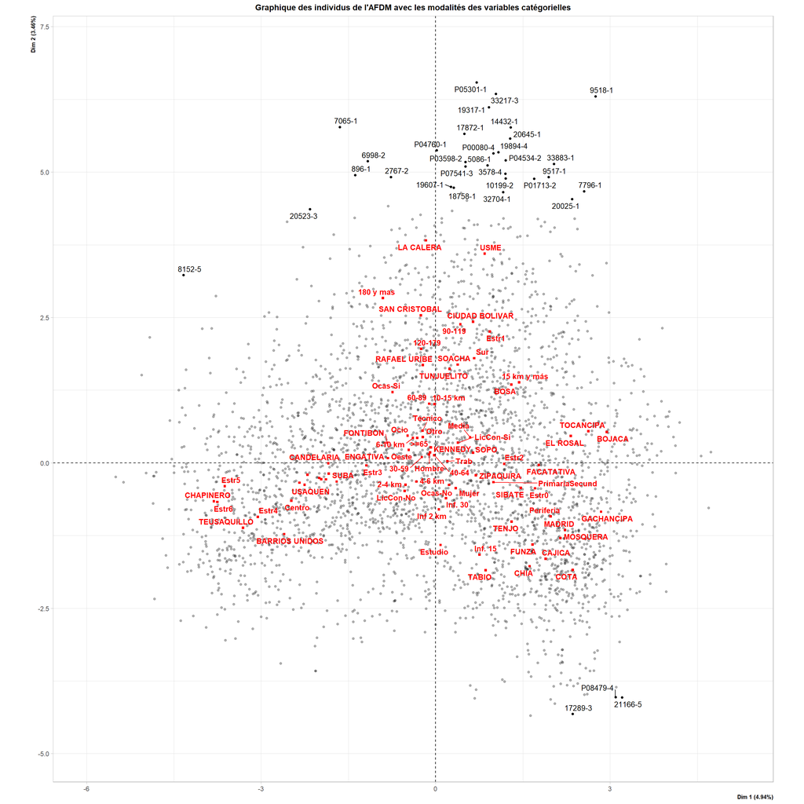

```r
res <- FAMD(Cyclistes, graph = FALSE)

contrib <- transform(data.frame(res$ind$contrib), contribPlan1 = Dim.1 + Dim.2)
selected_individuals <- rownames(contrib)[contrib$contribPlan1 >= quantile(contrib$contribPlan1, 0.99)] # création d'une liste d'individus dont les étiquettes seront affichées sur les graphiques (on n'en sélectionne que 1% ici pour ne pas allonger l'affichage des graphiques)
rm(contrib)

plot.FAMD(res, title = "Graphique des individus de l'AFDM avec les modalités des variables catégorielles", cex = 0.9, cex.main = 1, graph.type = "ggplot", cex.axis = 0.75, label = c('ind','quali.var'), select = selected_individuals)
```

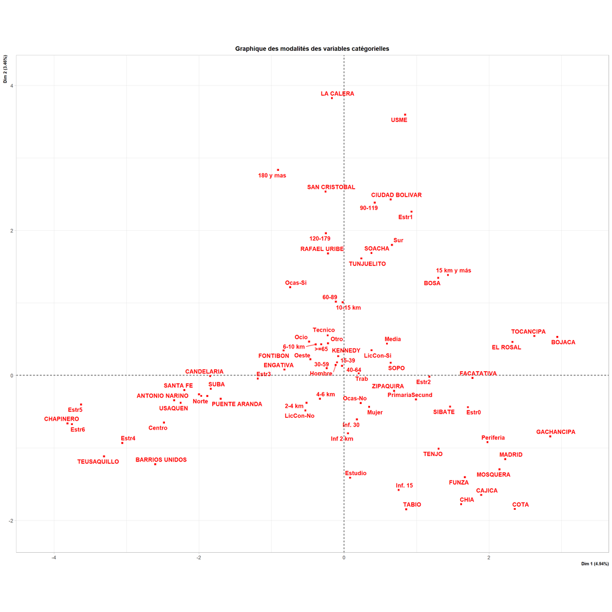

```r
plot.FAMD(res, title = "Graphique des modalités des variables catégorielles", cex = 0.9, cex.main = 1, graph.type = "ggplot", cex.axis = 0.75, invisible = "ind")
```

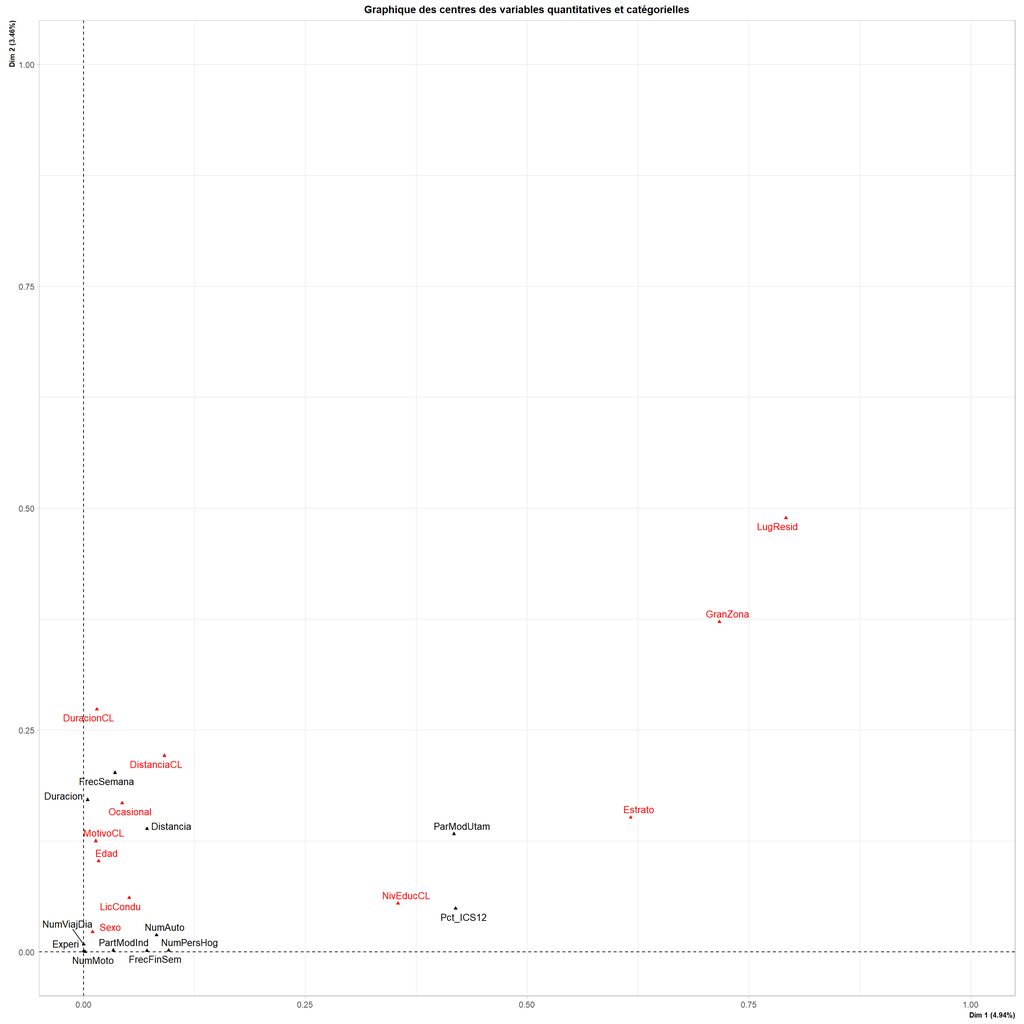

```r
plot.FAMD(res, choix = "var", title = "Graphique des centres des variables quantitatives et catégorielles", cex = 0.9, cex.main = 1, graph.type = "ggplot", cex.axis = 0.75)
```

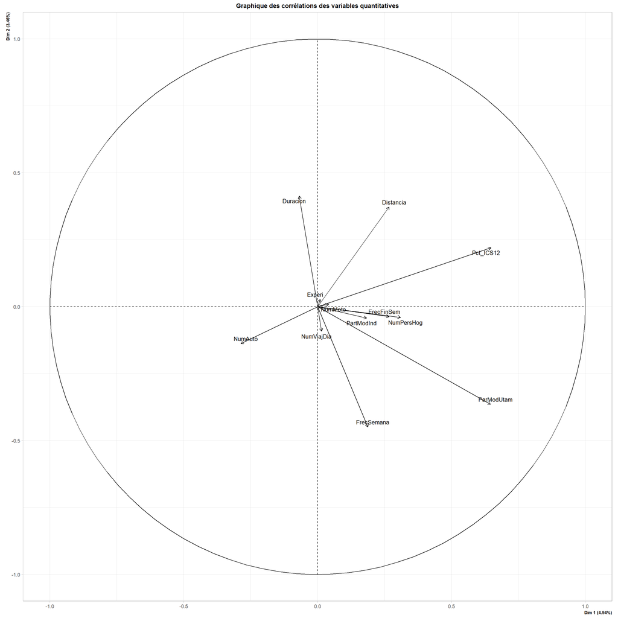

```r
plot.FAMD(res, choix = "quanti", title = "Graphique des corrélations des variables quantitatives", cex = 0.9, cex.main = 1, graph.type = "ggplot", cex.axis = 0.75)
```

## 1.4 Suppression des variables qui sont proches de l’origine du plan factoriel (peu discriminantes)

```r
Cyclistes$Experi <- NULL
Cyclistes$NumMoto <- NULL
Cyclistes$NumViajDia <- NULL
Cyclistes$PartModInd <- NULL
```

## 1.5 Affichage de la liste des variables restantes

```r
print(as.data.frame(colnames(Cyclistes)))
```

```
##    colnames(Cyclistes)
## 1                 Edad
## 2                 Sexo
## 3            NivEducCL
## 4             LicCondu
## 5            Ocasional
## 6           DuracionCL
## 7             MotivoCL
## 8              Estrato
## 9             LugResid
## 10            GranZona
## 11         DistanciaCL
## 12            Duracion
## 13           Distancia
## 14          FrecSemana
## 15          FrecFinSem
## 16             NumAuto
## 17          NumPersHog
## 18           Pct_ICS12
## 19          ParModUtam
```

## 1.6 Suppresion des individus qui ont des durées moyennes de trajet anormalement longues

```r
Cyclistes <- Cyclistes[Cyclistes$Duracion < 300,]
```

## 1.7 Deuxième calcul de l’AFDM après suppression des variables peu discriminantes et le passage de certaines variables en illustratif

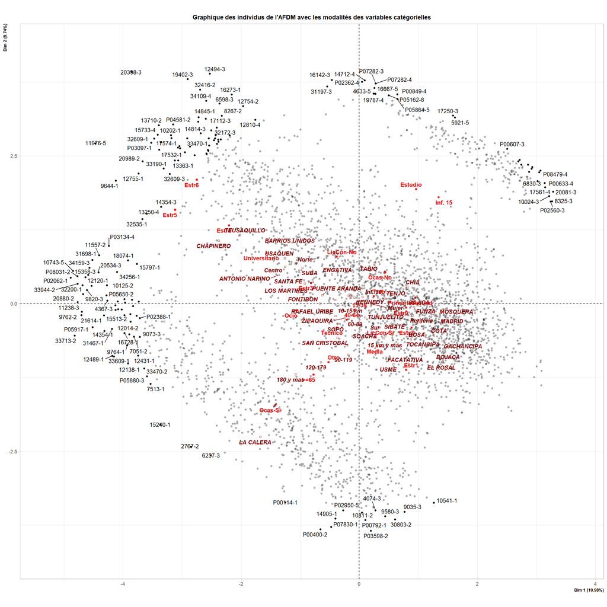

```r
res <- FAMD(Cyclistes, sup.var = c(2,6,9,10,11,15,17), graph = FALSE)

contrib <- transform(data.frame(res$ind$contrib), contribPlan1 = Dim.1 + Dim.2)
selected_individuals <- rownames(contrib)[contrib$contribPlan1 >= quantile(contrib$contribPlan1, 0.95)] # création d'une liste d'individus dont les étiquettes seront affichées sur les graphiques (on n'en sélectionne que 5% ici pour ne pas allonger l'affichage des graphiques)
rm(contrib)

plot.FAMD(res, title = "Graphique des individus de l'AFDM avec les modalités des variables catégorielles", cex = 0.9, cex.main = 1, graph.type = "ggplot", cex.axis = 0.75, label = c('ind','quali.var'), select = selected_individuals)
```

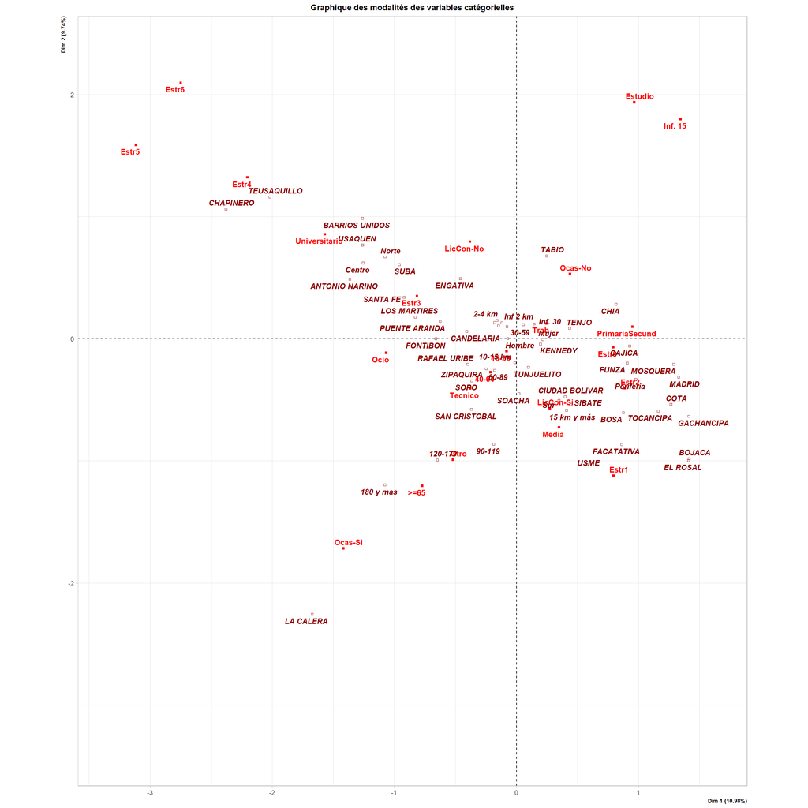

```r
plot.FAMD(res, title = "Graphique des modalités des variables catégorielles", cex = 0.9, cex.main = 1, graph.type = "ggplot", cex.axis = 0.75, invisible = "ind")
```

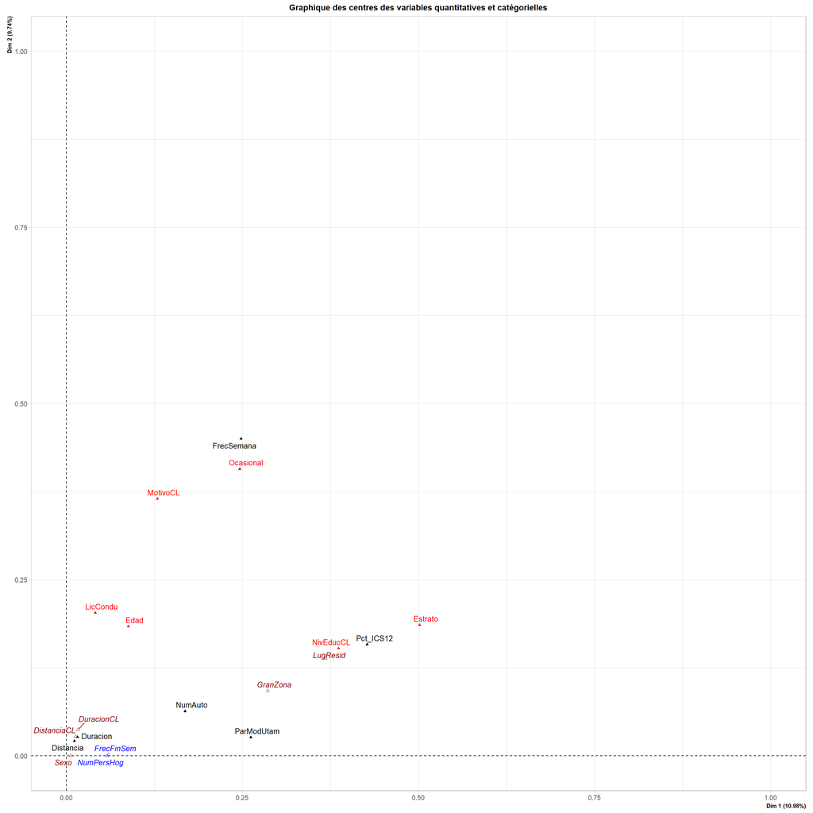

```r
plot.FAMD(res, choix = "var", title = "Graphique des centres des variables quantitatives et catégorielles", cex = 0.9, cex.main = 1, graph.type = "ggplot", cex.axis = 0.75)
```

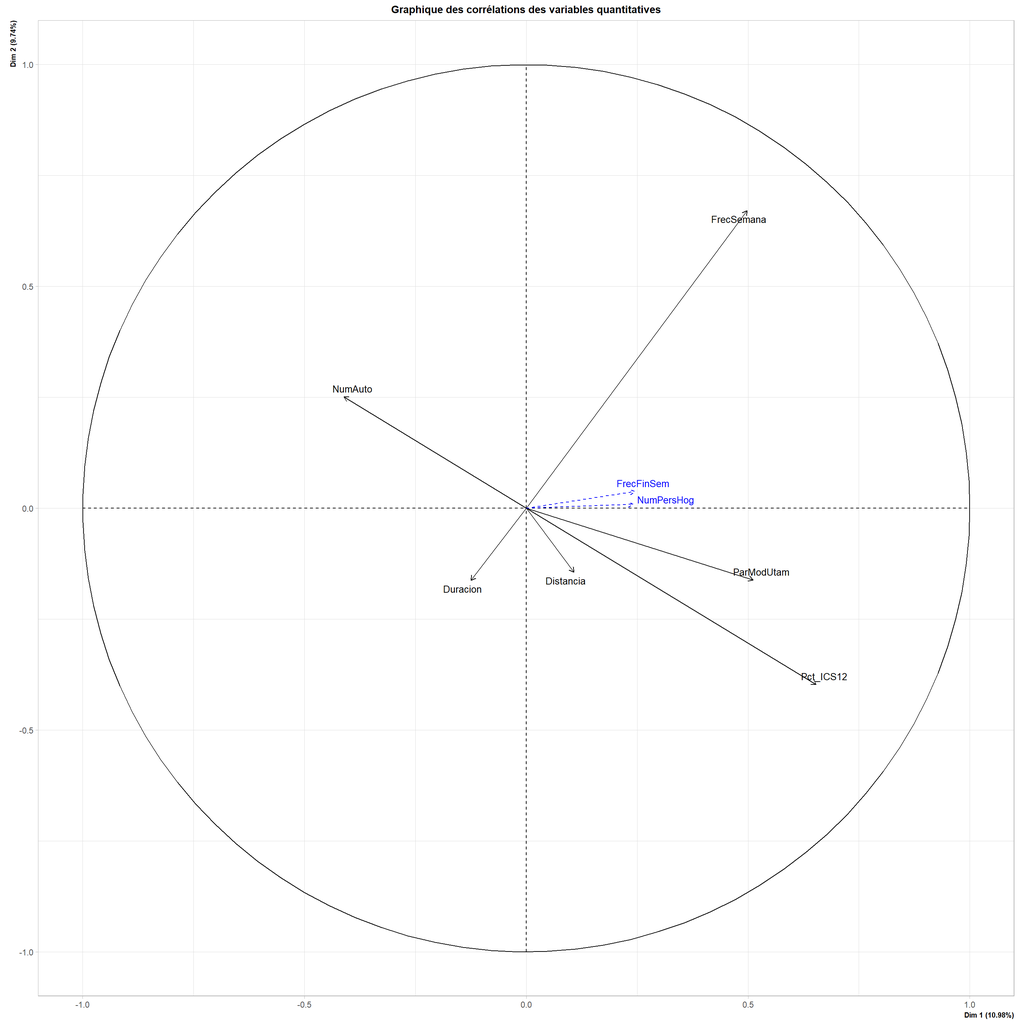

```r
plot.FAMD(res, choix = "quanti", title = "Graphique des corrélations des variables quantitatives", cex = 0.9, cex.main = 1, graph.type = "ggplot", cex.axis = 0.75)
```

## 1.8 Lancement de la CAH sur les résultats de l’AFDM

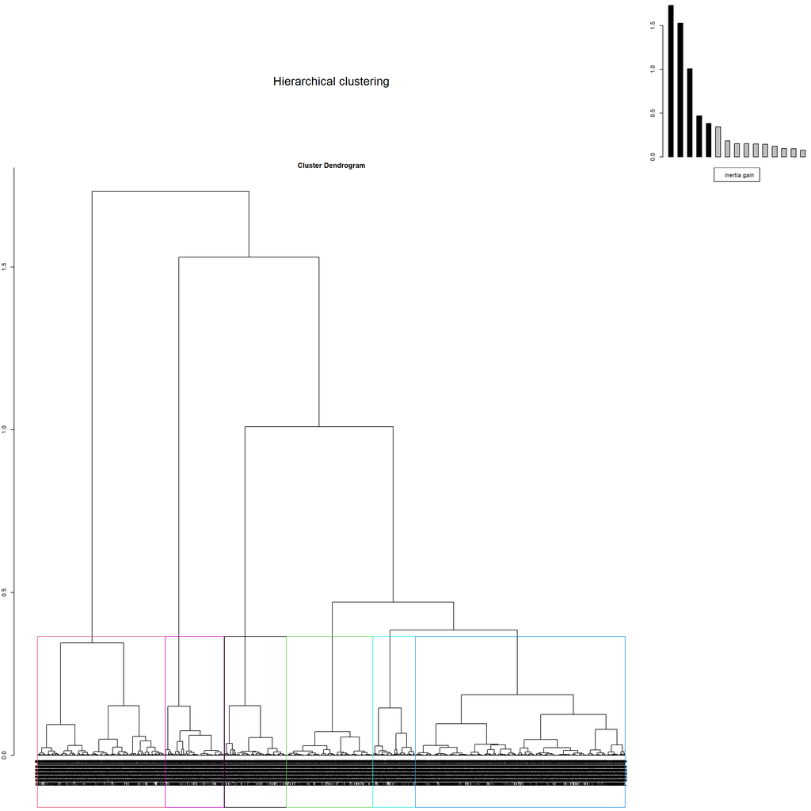

```r
nbclasses <- 6 # tester avec différents nombres de classes
res.hcpc <- HCPC(res, kk = Inf, nb.clust = nbclasses, consol = FALSE, graph = FALSE) # kk=inf signifie pas de partition préalable, consol=FALSE signifie qu'on n'applique pas à l'issue de la CAH une consolidation (par les k-means)
plot(res.hcpc, choice = "tree")
```

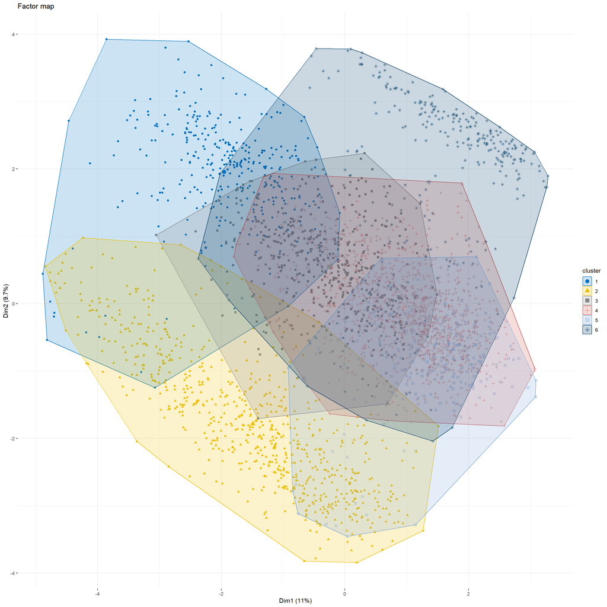

```r
fviz_cluster(res.hcpc,
  repel = TRUE,            # Avoid label overlapping
  show.clust.cent = TRUE,  # Show cluster centers
  palette = "jco",         # Color palette see ?ggpubr::ggpar
  ggtheme = theme_minimal(),
  main = "Factor map",
  geom = "point",         # Use points instead of labels
  geom_param = list(size = 5)  # Set the size of the points as desired
)
```

## 1.9 Calcul du tableau avec effectifs par classe et du diagramme en barres associé

```r
dataclust <- as.data.frame(res.hcpc[["data.clust"]])
IndividusClasse <- aggregate(NivEducCL ~ clust, dataclust, length) # pour créer un tableau avec le nombre d'individus par classe
print(IndividusClasse)
```

```
##   clust NivEducCL
## 1     1       339
## 2     2       696
## 3     3       471
## 4     4      1144
## 5     5       232
## 6     6       322
```

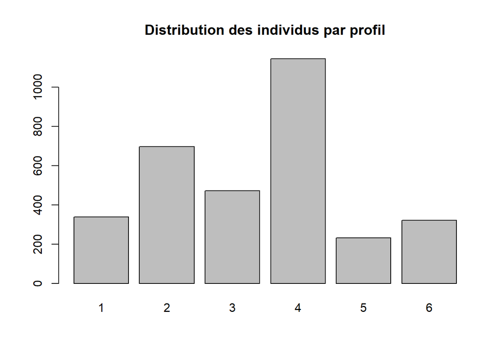

```r
barplot(IndividusClasse$NivEducCL, names = IndividusClasse$clust, main = "Distribution des individus par profil")
```

## 1.10 Identifier les variables catégorielles qui ne prennent que deux modalités

```r
# Cette opération est nécessaire pour simplifier ensuite les graphiques
TableauVariablesCategorielles <- Filter(is.character, Cyclistes)

NbModalitesParVariable <- data.frame()

for (i in colnames(TableauVariablesCategorielles)){

  # Récuperation du nombre de modalités pour chaque variable catégorielle
  fichier <- length(unique(TableauVariablesCategorielles[[i]]))
  NbModalitesParVariable <- rbind(NbModalitesParVariable, fichier)

}

rm(i, fichier)

NbModalitesParVariable$Variable <- colnames(TableauVariablesCategorielles)

VariablesDeuxModalites <- NbModalitesParVariable[which(NbModalitesParVariable[,1] == 2),]
VariablesDeuxModalites <- as.character(VariablesDeuxModalites$Variable)
```

## 1.11 Déterminer le seuil de la valeur v.test à retenir pour garder les variables qui décriront les classes

```r
# Par défaut v.test > |1.96| - Dans le cas présent relever le seuil permet de réduire le nombre de variables qui décriront les classes. On ne garde que celles qui sont extrêmement significatives
Seuil.v.test <- 3.29 # on accepte de se tromper une fois sur 1000
# en savoir plus https://www.medcalc.org/manual/values-of-the-normal-distribution.php
```

## 1.12 Création des tableaux décrivant les profils par les variables quanti et quali et affichage des diagrammes

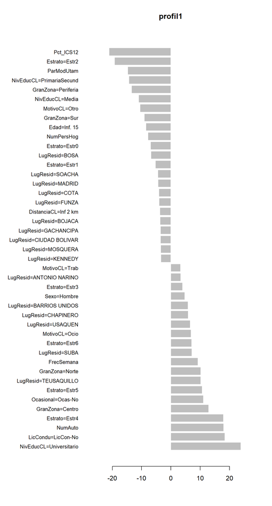

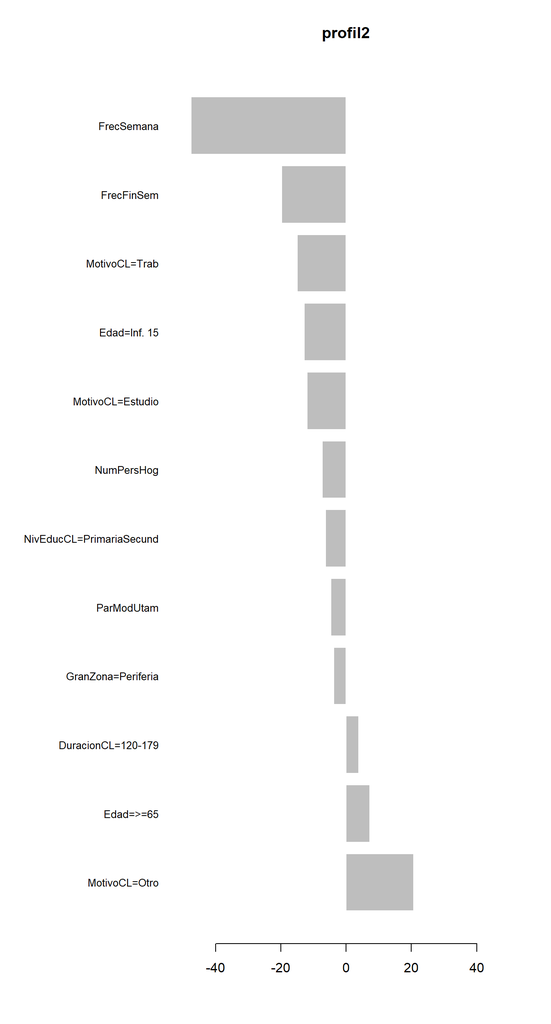

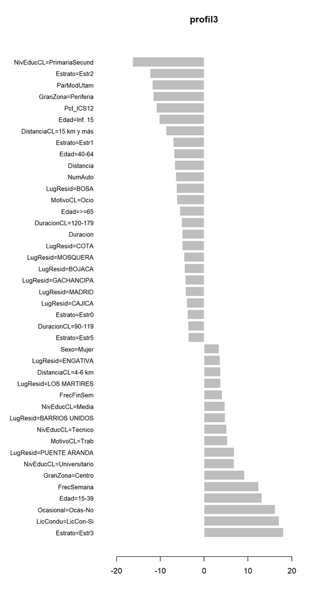

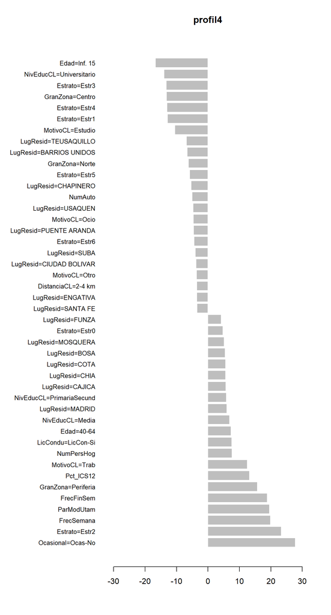

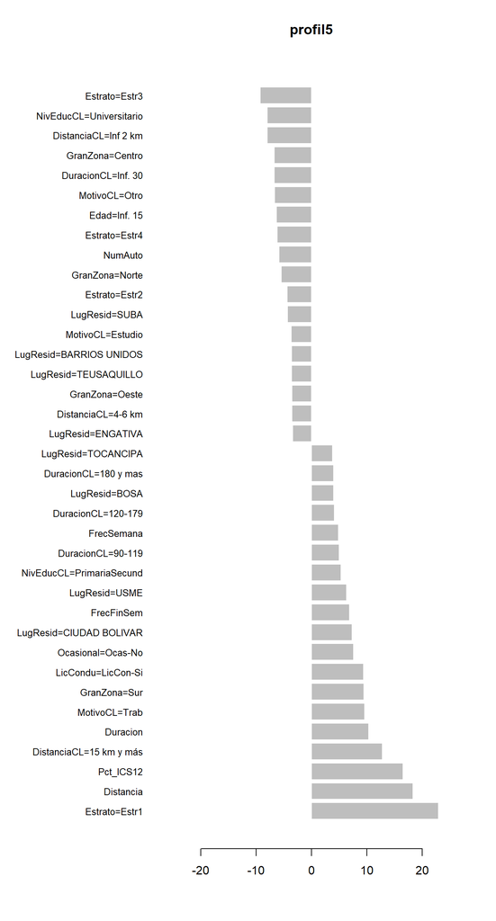

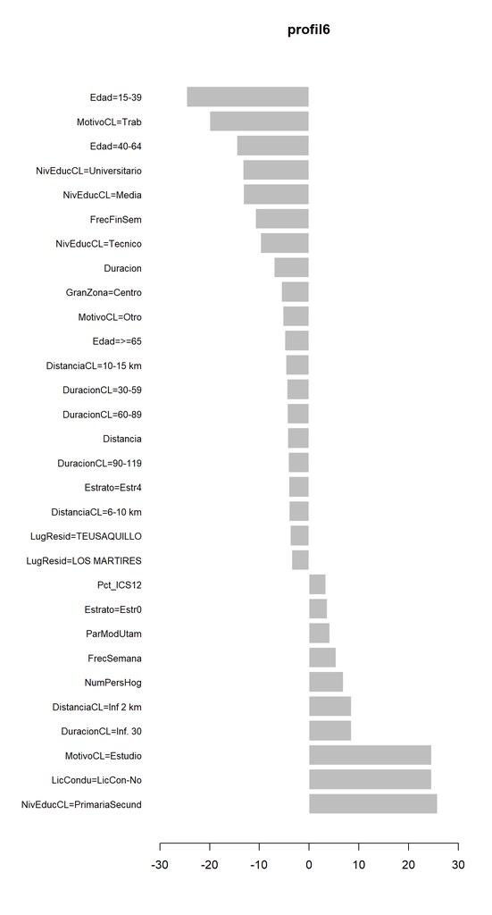

```r
# Pour les variables n'ayant que deux modalités, on n'en garde qu'une
for (i in 1:nbclasses){

  # Récuperation dans des tableaux de la description de chacune des N classes par les variables quanti
  b <- as.data.frame(res.hcpc$desc.var$quanti[[i]])
  b <- b[which(colnames(b) == 'v.test')]
  b <- signif(b,3) # pour arrondir les valeurs

  # Récuperation dans des tableaux de la description de chacune des N classes par les variables quali
  c <- as.data.frame(res.hcpc$desc.var$category[[i]])
  d <- as.data.frame(c$label <- rownames(c))
  d <- as.data.frame(c$label <- sub("\\=.*", "", c$label))
  d <- as.data.frame(c[which(c$label %in% VariablesDeuxModalites), ])
  d <- as.data.frame(d[which(d$v.test > 0),])
  e <- as.data.frame(c[which(!c$label %in% VariablesDeuxModalites), ])
  f <- as.data.frame(rbind(d, e))
  g <- as.data.frame(f$label <- NULL)
  c <- signif(f,3) # pour arrondir les valeurs
  c <- c[which(colnames(c) == 'v.test')]

  # Assemblage des tableaux avec les variables quanti et quali
  h <- as.data.frame(rbind(b,c))
  h <- as.data.frame(cbind(h, h$label <- row.names(h)))
  colnames(h) <- c("v.test", "label")
  h <- as.data.frame(h[order(h$v.test, decreasing = TRUE), ])
  h <- as.data.frame(h[which(!h$v.test == "Inf"),])
  h <- as.data.frame(h[which(abs(h$v.test) >= Seuil.v.test),])

  # pour tracer les diagrammes en barres horizontaux
  op <- par(oma = c(0,7,0,0))
  barplot((h$v.test), names = row.names(h), border = "white", horiz = TRUE, las = 1, xlim = c(-5 - max(abs(h$v.test)), 5 + max(abs(h$v.test))), cex.names=0.8, main = paste("profil", i, sep = ""))
  par(op)

}
```

```r
rm(b,c,d,e,f,g,h,i)
```

## 1.13 Extraction de l’identifiant des ménages (id_hog) à partir la colonne id_hog_pers

```r
# utile par la suite pour récupérer les coord. XY du lieu de résidence du ménage
Cyclistes$id_hog_pers <- row.names(dataclust)
df <- data.frame(x = Cyclistes$id_hog_pers)
df[c("id_hog", "id_pers")] <- do.call(rbind, strsplit(df$x, "-"))
Cyclistes$id_hog <- df$id_hog
rm(df)
```

## 1.14 Récupération dans le tableau initial du profil issu de la typologie

```r
Cyclistes$profil <- dataclust$clust
```

## 1.15 Export du tableau au format excel

```r
write.xlsx(Cyclistes, "TypoProfilCyclistesFINAL.xlsx")
#browseURL("TypoProfilCyclistesFINAL.xlsx")
```

# 2 Cartographie de la localisation des profils de cyclistes suivant leur lieu de résidence et de destination

## 2.1 Carte des lieux de résidence des cyclistes suivant leur profil

### 2.1.1 Préparation du jeu de données pour l’élaboration des cartes

#### 2.1.1.1 Importation des coordonnées XY du lieu de résidence des ménages comptant au moins un cycliste

```r
CoordXY_Menages <- read.xlsx("CoordXY_Menages.xlsx")
```

#### 2.1.1.2 Jointure des coordonnées XY du lieu de résidence dans le tableau des cyclistes

```r
Cyclistes <- merge(Cyclistes, CoordXY_Menages, by = "id_hog")
```

#### 2.1.1.3 Importation de la couche des UTAM (Unités Territoriales d’Analyse de la Mobilité)

```r
UTAM <- st_read("EMU2019_UTAM_Bgta.gpkg")
```

#### 2.1.1.4 Création d’un semis de points (objet sf) à partir des coordonnées XY du lieu de résidence des cyclistes

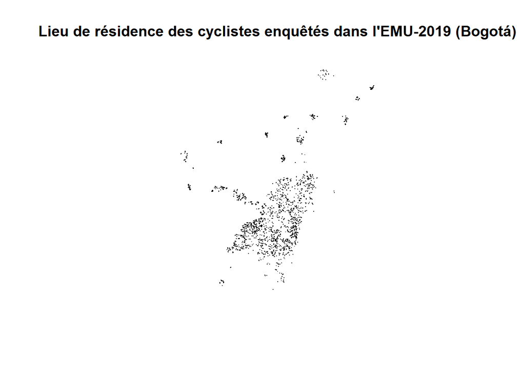

```r
ResidCyclistes<- st_as_sf(Cyclistes,
                          coords = c("X_Hog","Y_Hog"),
                          crs = st_crs(UTAM)$srid)
plot(st_geometry(ResidCyclistes), pch = ".", main = "Lieu de résidence des cyclistes enquêtés dans l'EMU-2019 (Bogotá)")
```

#### 2.1.1.5 Tri des profils

```r
# étape nécessaire en vue de créer des cartes de densité lissées donnant à voir la concentration des lieux de résidence des cyclistes suivant leur profil
## pour créer une liste des profils de cyclistes, dans l'ordre
Cyclistes <- Cyclistes[order(Cyclistes$profil, decreasing = FALSE), ]
ListProfils <- unique(Cyclistes$profil)
```

### 2.1.2 Série de cartes de densité montrant la concentration des lieux de résidence des cyclistes suivant leur profil

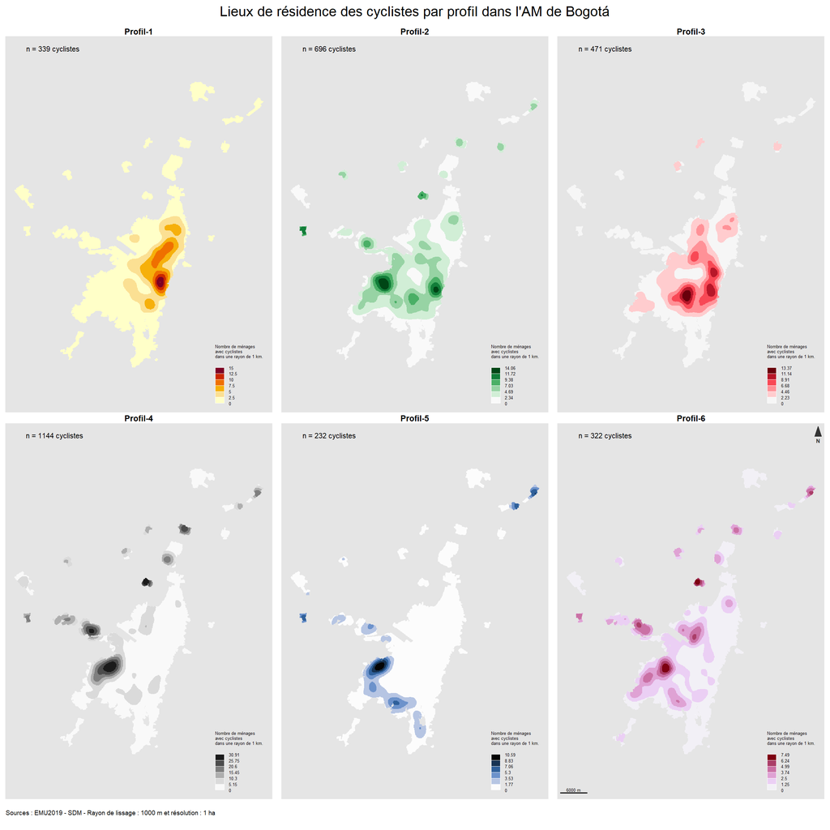

```r
# définition du nombre de classes
nclass <- 6

#création d'un ensemble de palettes de couleurs dans un objet "list"
pal <- list(
  pal1 = hcl.colors(nclass, "YlOrRd", rev = TRUE),
  pal2 = hcl.colors(nclass, "Greens 3", rev = TRUE),
  pal3 = hcl.colors(nclass, "Reds 3", rev = TRUE),
  pal4 = hcl.colors(nclass, "Grays", rev = TRUE),
  pal5 = hcl.colors(nclass, "Oslo", rev = FALSE),
  pal6 = hcl.colors(nclass, "Red-Purple", rev = TRUE),
  pal7 = hcl.colors(nclass, "Inferno", rev = TRUE),
  pal8 = hcl.colors(nclass, "Reds", rev = TRUE),
  pal9 = hcl.colors(nclass, "Blues 3", rev = TRUE),
  pal10 = hcl.colors(nclass, "Purples 3", rev = TRUE)
)

# pour définir comme emprise pour le lissage, l'étendue des UTAM
Emprise <- as.owin(st_buffer(st_geometry(UTAM), 1000))

# Paramétrage des marges pour insérer le titre général et les titres de chaque carte
par(oma = c(3.5,0,3,0)+0.1, mar = c(0, 0.5, 1.2, 0.5))

# pour découper la fenêtre en 2 lignes et 3 colonnes (6 profils)
par(mfrow = c(2,3))

# boucle pour produire et cartographier une surface de densité par profil
for (i in ListProfils){

  # Récuperation des jeux de données par profil
  fichier <- Cyclistes[which(Cyclistes$profil == i),]

  # pour récupérer les coordonnées des lieux de résidence
  pts <- st_coordinates(st_as_sf(fichier, coords = c("X_Hog","Y_Hog"), crs = st_crs(UTAM)$srid))

  # pour creer un objet ppp (format spatstat) et y integrer dedans l'emprise
  fichier.ppp <- ppp(pts[,1], pts[,2], window = Emprise)

  # pour définir la taille du rayon (en m.)
  rayon <- 1000

  # pour définir la taille du pixel (en m.)
  resol <- 100 # ici 100m x 100m = 1 ha.

  # pour calculer la surface de densité (rayon lissage : 1000 m et résolution spatiale de l'image : 100m x 100m = 1 ha)
  cartelissee <- density(fichier.ppp, sigma = rayon, kernel = "gaussian", eps = resol)

  # Conversion de la surface lissée au format SpatRaster
  cartelissee.raster <- rast(cartelissee)
  crs(cartelissee.raster) <- st_crs(UTAM)$srid # pour spécifier un SCR à l'objet raster

  # passage des densités à des effectifs (multiplication des densités par la surface du cercle)
  values(cartelissee.raster) <- abs(values(cartelissee.raster) * pi * rayon **2)

  # découpage du raster sur l'emprise des UTAM
  cartelissee.raster <- mask(cartelissee.raster, UTAM)

  # Définition des seuils de classes (intervalles égaux)
  bks <- seq(from = min(values(cartelissee.raster), na.rm = TRUE),
            to = max(values(cartelissee.raster), na.rm = TRUE),
            by = (max(values(cartelissee.raster), na.rm = TRUE) - min(values(cartelissee.raster), na.rm = TRUE)) / nclass)

  # reclassification de la surface lissée
  cartelissee.reclass <- classify(cartelissee.raster, rcl = bks)

  # vectorisation de la surface reclassée
  cartelissee.vecteur <- st_as_sf(as.polygons(cartelissee.reclass))

  # Tracer la carte
  plot(st_geometry(UTAM), border = "white", bg= "grey90")

  typoLayer(
    x = cartelissee.vecteur,
    var="lyr.1",
    col = unlist(pal[as.numeric(i)]),
    lwd = 0.1,
    border = unlist(pal[as.numeric(i)]),
    legend.pos = "n",
    add = TRUE)

  legendChoro(
         pos = "bottomright",
         title.txt = "Nombre de ménages\navec cyclistes\ndans une rayon de 1 km.",
         title.cex = 0.6,
         breaks = bks,
         values.rnd = 2,
         nodata = FALSE,
         col = unlist(pal[as.numeric(i)]),
         border = "white",
         horiz = FALSE
       )

  title(main = paste("Profil", i, sep = "-"))

  mtext(text = paste0("n = ", nrow(fichier), " cyclistes"),
      side = 3, line = -2, adj = 0.1, cex = 0.7)

}

barscale(
  lwd = 1.5,
  cex = 0.6,
  pos = "bottomleft",
  style = "pretty",
  unit = "m"
)

cartography::north(pos = "topright")

# Pour afficher le titre principal et la source
mtext("Lieux de résidence des cyclistes par profil dans l'AM de Bogotá", cex = 1.3, side = 3, line = 1, adj = 0.5, outer = TRUE)
mtext("   Sources : EMU2019 - SDM - Rayon de lissage : 1000 m et résolution : 1 ha", side = 1, line = 1, adj = 0, cex = 0.6, outer = TRUE)
```

```r
rm(i, fichier)
```

## 2.2 Carte des lieux d’arrivée du premier trajet en vélo depuis le domicile

```r
Destination1erTrajet <- st_read("Centroides_ZAT_Destination_1er_Trajet_Depuis_Domicile.gpkg")
```

### 2.2.1 Préparation du jeu de données

#### 2.2.1.1 Création d’une liste de personnes ayant au moins une destination connue

```r
listDestination1erTrajet <- as.character(Destination1erTrajet$id_concat)
```

#### 2.2.1.2 Sélection des personnes ayant une destination connue

```r
Cyclistes <- Cyclistes[Cyclistes$id_hog_pers %in% listDestination1erTrajet, ]
```

#### 2.2.1.3 Jointure pour récuperer le profil des cyclistes sur le lieu de destination

```r
Destination1erTrajet <- merge(Destination1erTrajet, Cyclistes[which(colnames(Cyclistes) %in% c("profil", "id_hog_pers"))], by.x = "id_concat", by.y = "id_hog_pers")
```

### 2.2.2 Création de la deuxième série de cartes par lieux de destination

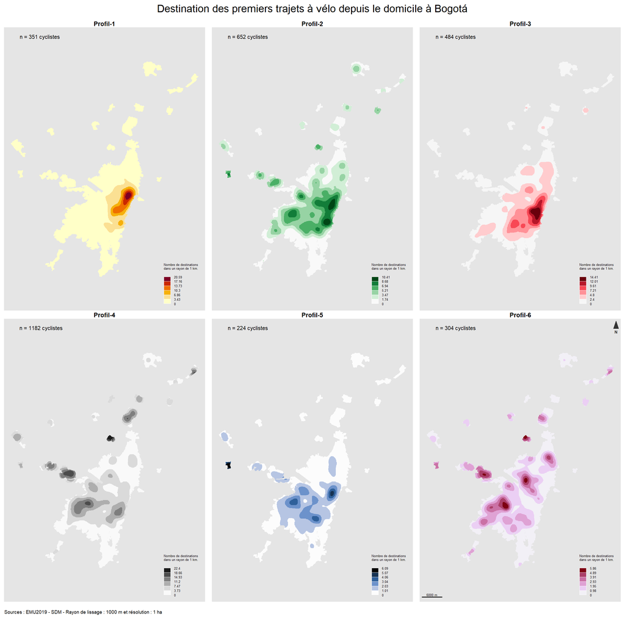

```r
# Paramétrage des marges pour insérer le titre général et les titres de chaque carte
par(oma = c(3.5,0,3,0)+0.1, mar = c(0, 0.5, 1.2, 0.5))

# pour découper la fenêtre en 2 lignes et 3 colonnes (6 profils)
par(mfrow = c(2,3))

# définition du nombre de classes
nclass <- 6

# boucle pour produire et cartographier une surface de densité par profil
for (i in ListProfils){

  # Récuperation des jeux de données par profil
  fichier <- Destination1erTrajet[which(Destination1erTrajet$profil == i),]

  # pour récupérer les coordonnées des lieux de résidence
  pts <- st_coordinates(fichier)

  # pour créer un objet ppp (format spatstat) et y intégrer dedans l'emprise
  fichier.ppp <- ppp(pts[,1], pts[,2], window = Emprise)

  # pour définir la taille du rayon (en m.)
  rayon <- 1000

  # pour définir la taille du pixel (en m.)
  resol <- 100 # ici 100m x 100m = 1 ha.

  # pour calculer la surface de densité (rayon lissage : 1000 m et resolution spatiale de l'image : 100m x 100m = 1 ha)
  cartelissee <- density(fichier.ppp, sigma = rayon, kernel = "gaussian", eps = resol)

  # Conversion de la surface lissée au format SpatRaster
  cartelissee.raster <- rast(cartelissee)
  crs(cartelissee.raster) <- st_crs(UTAM)$srid # pour spécifier un SCR à l'objet raster

  # passage des densités à des effectifs (multiplication des densités par la surface du cercle)
  values(cartelissee.raster) <- abs(values(cartelissee.raster) * pi * rayon **2)

  # découpage du raster sur l'emprise des UTAM
  cartelissee.raster <- mask(cartelissee.raster, UTAM)

  # Définition des seuils de classes (intervalles égaux)
  bks <- seq(from = min(values(cartelissee.raster), na.rm = TRUE),
            to = max(values(cartelissee.raster), na.rm = TRUE),
            by = (max(values(cartelissee.raster), na.rm = TRUE) - min(values(cartelissee.raster), na.rm = TRUE)) / nclass)

  # reclassification de la surface lissée
  cartelissee.reclass <- classify(cartelissee.raster, rcl = bks)

  # vectorisation de la surface reclassée
  cartelissee.vecteur <- st_as_sf(as.polygons(cartelissee.reclass))

  # Tracer la carte
  plot(st_geometry(UTAM), border = "white", bg= "grey90")

  typoLayer(
    x = cartelissee.vecteur,
    var= "lyr.1",
    col = unlist(pal[as.numeric(i)]),
    lwd = 0.1,
    border = unlist(pal[as.numeric(i)]),
    legend.pos = "n",
    add = TRUE)

  legendChoro(
         pos = "bottomright",
         title.txt = "Nombre de destinations\ndans un rayon de 1 km.",
         title.cex = 0.6,
         breaks = bks,
         values.rnd = 2,
         nodata = FALSE,
         col = unlist(pal[as.numeric(i)]),
         border = "white",
         horiz = FALSE
       )

  title(main = paste("Profil", i, sep = "-"))

  mtext(text = paste0("n = ", nrow(fichier), " cyclistes"),
      side = 3, line = -2, adj = 0.1, cex = 0.7)

}

barscale(
  lwd = 1.5,
  cex = 0.6,
  pos = "bottomleft",
  style = "pretty",
  unit = "m"
)

cartography::north(pos = "topright")

# Pour afficher le titre principal et la source
mtext("Destination des premiers trajets à vélo depuis le domicile à Bogotá", cex = 1.3, side = 3, line = 1, adj = 0.5, outer = TRUE)
mtext("   Sources : EMU2019 - SDM - Rayon de lissage : 1000 m et résolution : 1 ha", side = 1, line = 1, adj = 0, cex = 0.6, outer = TRUE)
```

```r
rm(i, fichier)
```